# Homework 11

By 19086

2019-12-25

## Question AR2

1. You have already written an R function for Exercise 9.4 (page 277, Statistical Computing with R). Rewrite an Rcpp function for the same task.
2. Compare the generated random numbers by the two functions using qqplot.
3. Campare the computation time of the two functions with microbenchmark.
4. Comments your results.

### Exercise 9.4

Implement a random walk Metropolis sampler for generating the standard Laplace distribution (see Exercise 3.2). For the increment, simulate from a normal distribution. Compare the chains generated when different variances are used for the proposal distribution. Also, compute the acceptance rates of each chain.

## Answer AR2

Implement the random walk version of the Metropolis sampler to generate the target distribution standard Laplace $l$, using the proposal distribution $Normal(X_t, \sigma^2)$. In order to see the effect of different choices of variance of the proposal distribution, try repeating the simulation with different choices of $\sigma$.

The standard Laplace distribution $l$ is $f(x)=\frac{1}{2}e^{-|x|} \propto e^{-|x|}$, for $x\in\mathbb{R}$. So
$$\begin{equation}
r(x_t, y) = \frac{f(Y)}{f(X_t)} = \frac{e^{-|y|}}{e^{-|x_t|}}
\end{equation}$$

### R version

In this simulation below, the Laplace densities in $r(x_{i-1}, y)$ will be computed by *dlaplace* as following

```r
dlaplace <- function(x) exp(-abs(x))
```

Also, it can be implemented by *dlaplace* function in package *rmutil*.

Then $y$ is accepted or rejected and $X_i$ generated by

```r
if (u[i] <= dt(y, n) / dt(x[i-1], n))
  x[i] <- y
else
  x[i] <- x[i-1]
```

```r
rw.Metropolis <- function(sigma, x0, N) {
  x <- numeric(N)
  x[1] <- x0
  u <- runif(N)
  k <- 0
  for (i in 2:N) {
    y <- rnorm(1, x[i-1], sigma)
    if (u[i] <= (dlaplace(y) / dlaplace(x[i-1])))
      x[i] <- y else {
      x[i] <- x[i-1]
      k <- k + 1
    }
  }
  return(list(x=x, k=k))
}
```

### Rcpp version

This is the cpp code.

Note that, NumericVector should to convert to a double using [0].

```c
#include <Rcpp.h>
using namespace Rcpp;
// [[Rcpp::export]]
List rw_Metropolis(double sigma, double x0, int N) {
    NumericVector x(N);
    x[0] = x0;
    Function myrunif("runif");
    Function myrnorm("rnorm");
    NumericVector u = myrunif(Named("n") = N);
    int k = 0;
    for (int i=1; i<N; i++) {
        NumericVector y = myrnorm(Named("n")=1, Named("mean")=x[i-1], Named("sd")=sigma);
        if (u[i] <= (exp(abs(x[i-1]) - abs(y[0])))) {
            x[i] = y[0];
        } else {
            x[i] = x[i-1];
            k++;
        }
    }
    return List::create(Named("x")=x, Named("k")=k);
}
```

This is r code, using rcpp to call the cpp code above.

```r
library(Rcpp) # Attach R package "Rcpp"

# Define function in rw_Metropolis.cpp
sourceCpp("./rw_Metropolis.cpp")

set.seed(12345)

# data preparation, setting 1
N <- 2000
sigma <- c(.05, .5, 2, 16)

x0 <- 25
rw1 <- rw_Metropolis(sigma[1], x0, N)
rw2 <- rw_Metropolis(sigma[2], x0, N)
rw3 <- rw_Metropolis(sigma[3], x0, N)
rw4 <- rw_Metropolis(sigma[4], x0, N)

cat(" Accept rate: \n", 1-c(rw1$k /N, rw2$k /N, rw3$k /N, rw4$k /N))
```

```
##  Accept rate:
##  0.9855 0.869 0.575 0.1125
```

Four chains are generated for different variances $\sigma^2$ of the proposal distribution.

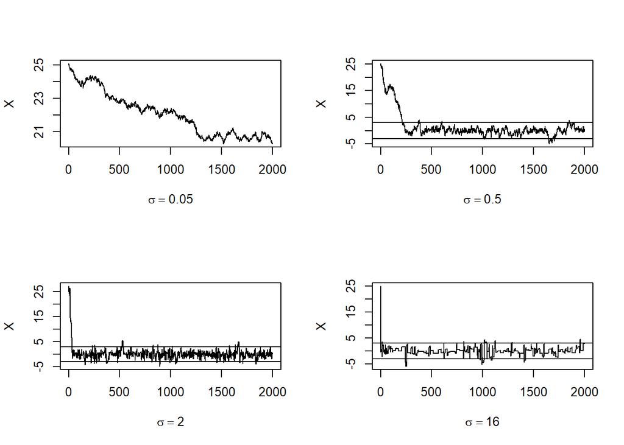

```r
library(rmutil)                       # for qlaplace
refline <- qlaplace(c(.025, .975))    # target quantile value

par(mfrow=c(2,2))
plot(1:N, rw1$x, "l", xlab=expression(sigma==0.05), ylab="X")
abline(h=refline)
plot(1:N, rw2$x, "l", xlab=expression(sigma==0.5), ylab="X")
abline(h=refline)
plot(1:N, rw3$x, "l", xlab=expression(sigma==2), ylab="X")
abline(h=refline)
plot(1:N, rw4$x, "l", xlab=expression(sigma==16), ylab="X")
abline(h=refline)
```

Usually in MCMC problems one does not have the theoretical quantiles of the target distribution available for comparison, but in this case the output of the random walk Metropolis chains above can be compared with the theoretical quantiles of the target distribution. Discard the burn-in values in the first $500$ rows of each chain. The quantiles are computed by the **apply* function (applying quantile to the columns of the matrix). The quantiles of the target distribution and the sample quantiles of the four chains *rw1*, *rw2*, *rw3*, and *rw4* are in the following table.

```r
library(rmutil)                           # for laplace distribution
a <- c(.05, seq(.1, .9, .1), .95)         # quantile points
Q <- qlaplace(a)                          # theritical quantiles
rw <- cbind(rw1$x, rw2$x, rw3$x, rw4$x)
mc <- rw[501:N, ]
Qrw <- apply(mc, 2, function(x) quantile(x, a))  # calculate rw quantiles
# print(round(cbind(Q, Qrw), 3))          # for command line
# xtable::xtable(round(cbind(Q, Qrw), 3)) # latex format for pdf
kable(round(cbind(Q, rw1=Qrw[,1], rw2=Qrw[,2], rw3=Qrw[,3], rw4=Qrw[,4]), 3), caption="Quantiles of Target Distribution and Chines")
```

Quantiles of Target Distribution and Chines

|  | Q | rw1 | rw2 | rw3 | rw4 |
| --- | --- | --- | --- | --- | --- |
| 5% | -2.303 | 20.478 | -2.636 | -2.204 | -2.498 |
| 10% | -1.609 | 20.539 | -1.767 | -1.712 | -1.939 |
| 20% | -0.916 | 20.626 | -0.929 | -0.958 | -0.827 |
| 30% | -0.511 | 20.722 | -0.614 | -0.651 | -0.663 |
| 40% | -0.223 | 20.863 | -0.351 | -0.256 | -0.327 |
| 50% | 0.000 | 21.200 | -0.039 | 0.053 | -0.074 |
| 60% | 0.223 | 21.900 | 0.286 | 0.357 | 0.200 |
| 70% | 0.511 | 22.152 | 0.618 | 0.604 | 0.568 |
| 80% | 0.916 | 22.353 | 0.874 | 0.914 | 0.860 |
| 90% | 1.609 | 22.550 | 1.473 | 1.676 | 1.579 |
| 95% | 2.303 | 22.681 | 1.906 | 2.441 | 2.728 |